# Final Project Data Processing

Load Library and reading the cleaned census data, where we only included 4 columns: AGEGRP: age (in groups); LFACT: labor force detail; YRIM: year of Immigration; IMMSTAT: immigrant status. These are the main columns that we will be performing our analysis on and try to explore the causal relationship.

```r
rm(list=ls())

library(tidyverse)
library(haven)
library(stargazer)
```

```r
library(ggplot2)
library(dplyr)

#Data Subsetting (previous preparatory work, commented out here)
#df_basic_d_y <- df |>
  #select(AGEGRP, LFACT, YRIM, IMMSTAT)

#head(df_basic_d_y)
#library(readr)

# write to a file called “df_basic_d_y.csv” in your working directory
#write_csv(df_basic_d_y, "cen_2021_clean.csv")

#Read in the cleaned dataset:
df <- read_csv("data/cen_2021_clean.csv")
head(df)
```

| AGEGRP | LFACT | YRIM | IMMSTAT |
| --- | --- | --- | --- |
| 13 | 88 | 2008 | 88 |
| 11 | 3 | 2005 | 2 |
| 13 | 14 | 9999 | 1 |
| 16 | 13 | 9999 | 1 |
| 18 | 13 | 9999 | 1 |
| 16 | 13 | 9999 | 1 |

Data cleaning Process: 1) coerce all the PUMF code‐vars to numeric in one go 2) drop the “never worked” & missing codes in LFACT 3) keep only citizens or immigrants 4) restrict to the age groups you care about (AGEGRP 13–19) 5) create the Retired outcome variable (Yi)

```r
# df without useless columns (at the moment)
df_clean <- df %>%
  mutate(across(
    c(AGEGRP, LFACT, IMMSTAT, YRIM),
    ~ as.numeric(.)
  )) %>%

  filter(! LFACT %in% c(14, 88, 99)) %>%

  filter(IMMSTAT %in% c(1, 2)) %>%

  filter(AGEGRP >= 13, AGEGRP <= 19) %>%

  mutate(
    Retired = if_else(LFACT %in% c(11, 12, 13), 1L, 0L)
  )
head(df_clean)
```

| AGEGRP | LFACT | YRIM | IMMSTAT | Retired |
| --- | --- | --- | --- | --- |
| 16 | 13 | 9999 | 1 | 1 |
| 18 | 13 | 9999 | 1 | 1 |
| 16 | 13 | 9999 | 1 | 1 |
| 16 | 13 | 9 | 2 | 1 |
| 16 | 13 | 9999 | 1 | 1 |
| 13 | 1 | 9999 | 1 | 0 |

# Quick check:

```r
df_clean %>%
  count(LFACT)     # should only see 1–13
```

| LFACT | n |
| --- | --- |
| 1 | 192662 |
| 2 | 9486 |
| 3 | 4816 |
| 4 | 3782 |
| 5 | 929 |
| 6 | 1316 |
| 7 | 616 |
| 8 | 204 |
| 9 | 6251 |
| 10 | 2159 |

[output cut: 3 more lines]

```r
df_clean %>%
  count(IMMSTAT)   # only 1,2
```

| IMMSTAT | n |
| --- | --- |
| 1 | 270777 |
| 2 | 105133 |

```r
df_clean %>%
  count(AGEGRP)    # only 13–19
```

| AGEGRP | n |
| --- | --- |
| 13 | 58613 |
| 14 | 60607 |
| 15 | 68034 |
| 16 | 64749 |
| 17 | 53613 |
| 18 | 42635 |
| 19 | 27659 |

```r
df_clean %>%
  count(Retired)   # retired vs. not
```

| Retired | n |
| --- | --- |
| 0 | 222221 |
| 1 | 153689 |

Separating treatment/ control group

```r
df_did <- df_clean %>%
  # define group membership once and for all
  mutate(
    eligible = as.integer(
      IMMSTAT == 1                          # all citizens
      | (IMMSTAT == 2 & YRIM <= 2011)      # immigrants ≥10 yrs
    ),
    post = as.integer(AGEGRP > 16),        # age 65+ if AGEGRP 17+
    did  = eligible * post                 # the actual treatment
  )
```

summary statistics

```r
summary(df_did)
```

```
##      AGEGRP          LFACT             YRIM         IMMSTAT
##  Min.   :13.00   Min.   : 1.000   Min.   :   1   Min.   :1.00
##  1st Qu.:14.00   1st Qu.: 1.000   1st Qu.:2011   1st Qu.:1.00
##  Median :16.00   Median : 1.000   Median :9999   Median :1.00
##  Mean   :15.62   Mean   : 6.125   Mean   :7453   Mean   :1.28
##  3rd Qu.:17.00   3rd Qu.:13.000   3rd Qu.:9999   3rd Qu.:2.00
##  Max.   :19.00   Max.   :13.000   Max.   :9999   Max.   :2.00
##     Retired          eligible           post             did
##  Min.   :0.0000   Min.   :0.0000   Min.   :0.0000   Min.   :0.0000
##  1st Qu.:0.0000   1st Qu.:1.0000   1st Qu.:0.0000   1st Qu.:0.0000
##  Median :0.0000   Median :1.0000   Median :0.0000   Median :0.0000
##  Mean   :0.4088   Mean   :0.9731   Mean   :0.3296   Mean   :0.3253
##  3rd Qu.:1.0000   3rd Qu.:1.0000   3rd Qu.:1.0000   3rd Qu.:1.0000
##  Max.   :1.0000   Max.   :1.0000   Max.   :1.0000   Max.   :1.0000
```

```r
# 2. Summarise retirement rates by age and group
df_trends <- df_did %>%
  group_by(AGEGRP, eligible) %>%
  summarise(
    prop_retire = mean(Retired),
    .groups = "drop"
  )
```

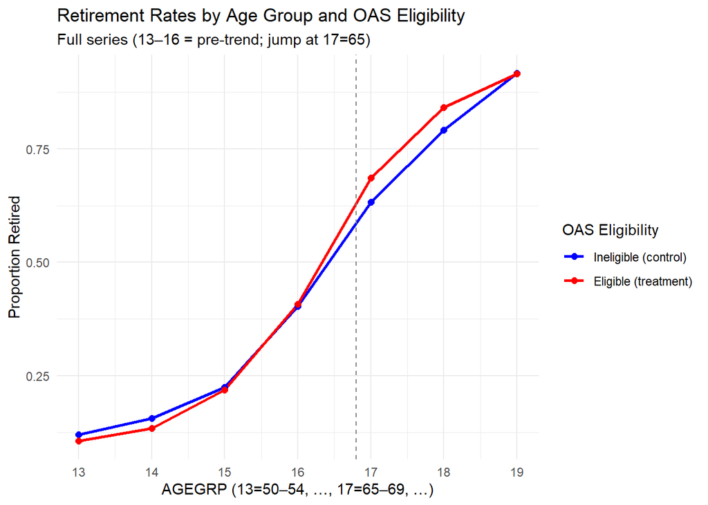

```r
#Chat-GPT helped with the plotting partially
ggplot(df_trends, aes(x = AGEGRP, y = prop_retire, color = factor(eligible))) +
  geom_line(size = 1) +
  geom_point(size = 2) +
  geom_vline(xintercept = 16.8, linetype = "dashed", color = "grey50") +
  scale_color_manual(
    values = c("blue", "red"),
    labels = c("Ineligible (control)", "Eligible (treatment)"),
    name   = "OAS Eligibility"
  ) +
  scale_x_continuous(breaks = 13:19) +
  labs(
    title    = "Retirement Rates by Age Group and OAS Eligibility",
    subtitle = "Full series (13–16 = pre-trend; jump at 17=65)",
    x        = "AGEGRP (13=50–54, …, 17=65–69, …)",
    y        = "Proportion Retired"
  ) +
  theme_minimal()
```

```r
# CTA-Restrict to pre‐treatment period: AGEGRP ≤ 16 (i.e. all below age‐65)
pre_df <- df_did %>%
  filter(AGEGRP <= 16)

# Factor‐by‐factor approach
ct_fac <- lm(Retired ~ eligible * factor(AGEGRP), data = pre_df)
summary(ct_fac)
```

```
##
## Call:
## lm(formula = Retired ~ eligible * factor(AGEGRP), data = pre_df)
##
## Residuals:
##     Min      1Q  Median      3Q     Max
## -0.4078 -0.2195 -0.1340 -0.1061  0.8939
##
## Coefficients:
##                            Estimate Std. Error t value Pr(>|t|)
## (Intercept)                0.120488   0.006418  18.774  < 2e-16 ***
## eligible                  -0.014374   0.006640  -2.165 0.030393 *
## factor(AGEGRP)14           0.035437   0.010351   3.424 0.000618 ***
## factor(AGEGRP)15           0.104512   0.012563   8.319  < 2e-16 ***
## factor(AGEGRP)16           0.283099   0.014799  19.130  < 2e-16 ***
## eligible:factor(AGEGRP)14 -0.007552   0.010619  -0.711 0.476982
## eligible:factor(AGEGRP)15  0.008905   0.012771   0.697 0.485605
## eligible:factor(AGEGRP)16  0.018636   0.014980   1.244 0.213473
## ---
## Signif. codes:  0 '***' 0.001 '**' 0.01 '*' 0.05 '.' 0.1 ' ' 1
##
## Residual standard error: 0.3983 on 251995 degrees of freedom
## Multiple R-squared:  0.07992,    Adjusted R-squared:  0.07989
## F-statistic:  3127 on 7 and 251995 DF,  p-value: < 2.2e-16
```

immigrant only: compare between treatment immigrants and control immigrants

```r
df_imm_only <- df_clean %>%
  # get rid of citizen
  filter(
    IMMSTAT == 2
  ) %>%
  # define group membership once and for all
  mutate(
    eligible = as.integer(YRIM <= 2011     # immigrants ≥10 yrs
    ),
    post = as.integer(AGEGRP > 16),        # age 65+ if AGEGRP 17+
    did  = eligible * post                 # the actual treatment
  )
```

```r
summary(df_imm_only)
```

```
##      AGEGRP          LFACT             YRIM           IMMSTAT     Retired
##  Min.   :13.00   Min.   : 1.000   Min.   :   1.0   Min.   :2   Min.   :0.0000
##  1st Qu.:14.00   1st Qu.: 1.000   1st Qu.:   6.0   1st Qu.:2   1st Qu.:0.0000
##  Median :15.00   Median : 1.000   Median :   9.0   Median :2   Median :0.0000
##  Mean   :15.51   Mean   : 5.729   Mean   : 894.8   Mean   :2   Mean   :0.3691
##  3rd Qu.:17.00   3rd Qu.:13.000   3rd Qu.:2003.0   3rd Qu.:2   3rd Qu.:1.0000
##  Max.   :19.00   Max.   :13.000   Max.   :8888.0   Max.   :2   Max.   :1.0000
##     eligible           post             did
##  Min.   :0.0000   Min.   :0.0000   Min.   :0.0000
##  1st Qu.:1.0000   1st Qu.:0.0000   1st Qu.:0.0000
##  Median :1.0000   Median :0.0000   Median :0.0000
##  Mean   :0.9037   Mean   :0.3152   Mean   :0.2998
##  3rd Qu.:1.0000   3rd Qu.:1.0000   3rd Qu.:1.0000
##  Max.   :1.0000   Max.   :1.0000   Max.   :1.0000
```

```r
# 2. Summarise retirement rates by age and group
df_trends_imm <- df_imm_only %>%
  group_by(AGEGRP, eligible) %>%
  summarise(
    prop_retire = mean(Retired),
    .groups = "drop"
  )
```

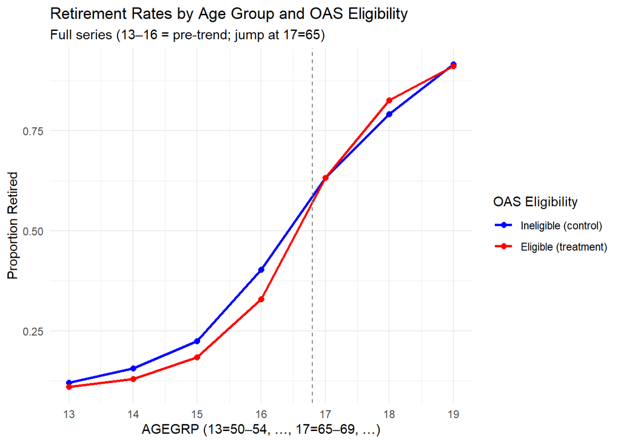

```r
#Chat-GPT helped with the plotting partially
ggplot(df_trends_imm, aes(x = AGEGRP, y = prop_retire, color = factor(eligible))) +
  geom_line(size = 1) +
  geom_point(size = 2) +
  geom_vline(xintercept = 16.8, linetype = "dashed", color = "grey50") +
  scale_color_manual(
    values = c("blue", "red"),
    labels = c("Ineligible (control)", "Eligible (treatment)"),
    name   = "OAS Eligibility"
  ) +
  scale_x_continuous(breaks = 13:19) +
  labs(
    title    = "Retirement Rates by Age Group and OAS Eligibility",
    subtitle = "Full series (13–16 = pre-trend; jump at 17=65)",
    x        = "AGEGRP (13=50–54, …, 17=65–69, …)",
    y        = "Proportion Retired"
  ) +
  theme_minimal()
```

```r
# CTA-Restrict to pre‐treatment period(imm only): AGEGRP ≤ 16 (i.e. all below age‐65)
pre_df_imm <- df_imm_only %>%
  filter(AGEGRP <= 16)

# Factor‐by‐factor approach
ct_fac <- lm(Retired ~ eligible * factor(AGEGRP), data = pre_df_imm)
summary(ct_fac)
```

```
##
## Call:
## lm(formula = Retired ~ eligible * factor(AGEGRP), data = pre_df_imm)
##
## Residuals:
##     Min      1Q  Median      3Q     Max
## -0.4036 -0.1842 -0.1304 -0.1097  0.8903
##
## Coefficients:
##                            Estimate Std. Error t value Pr(>|t|)
## (Intercept)                0.120488   0.006110  19.719  < 2e-16 ***
## eligible                  -0.010776   0.006857  -1.572 0.116043
## factor(AGEGRP)14           0.035437   0.009855   3.596 0.000323 ***
## factor(AGEGRP)15           0.104512   0.011960   8.738  < 2e-16 ***
## factor(AGEGRP)16           0.283099   0.014090  20.093  < 2e-16 ***
## eligible:factor(AGEGRP)14 -0.014763   0.010740  -1.375 0.169275
## eligible:factor(AGEGRP)15 -0.029998   0.012692  -2.364 0.018104 *
## eligible:factor(AGEGRP)16 -0.063217   0.014766  -4.281 1.86e-05 ***
## ---
## Signif. codes:  0 '***' 0.001 '**' 0.01 '*' 0.05 '.' 0.1 ' ' 1
##
## Residual standard error: 0.3792 on 71991 degrees of freedom
## Multiple R-squared:  0.04633,    Adjusted R-squared:  0.04624
## F-statistic: 499.6 on 7 and 71991 DF,  p-value: < 2.2e-16
```

## Regression models

1. baseline (additive) model for citizen-immigrant dataset:

```r
lm_baseline_c_i <- lm(Retired~ post + eligible, data=df_did)

summary(lm_baseline_c_i)
```

```
##
## Call:
## lm(formula = Retired ~ post + eligible, data = df_did)
##
## Residuals:
##     Min      1Q  Median      3Q     Max
## -0.7907 -0.2230 -0.2230  0.2093  0.8236
##
## Coefficients:
##             Estimate Std. Error t value Pr(>|t|)
## (Intercept) 0.176353   0.004106   42.95   <2e-16 ***
## post        0.567677   0.001434  395.88   <2e-16 ***
## eligible    0.046631   0.004163   11.20   <2e-16 ***
## ---
## Signif. codes:  0 '***' 0.001 '**' 0.01 '*' 0.05 '.' 0.1 ' ' 1
##
## Residual standard error: 0.4125 on 375907 degrees of freedom
## Multiple R-squared:  0.2959, Adjusted R-squared:  0.2959
## F-statistic: 7.898e+04 on 2 and 375907 DF,  p-value: < 2.2e-16
```

2.1 did linear probability model for citizen-immigrant dataset:

```r
lm_did_c_i <- lm(Retired~ post * eligible, data=df_did)

summary(lm_did_c_i)
```

```
##
## Call:
## lm(formula = Retired ~ post * eligible, data = df_did)
##
## Residuals:
##     Min      1Q  Median      3Q     Max
## -0.7907 -0.2230 -0.2230  0.2093  0.8231
##
## Coefficients:
##               Estimate Std. Error t value Pr(>|t|)
## (Intercept)   0.176892   0.004472  39.552   <2e-16 ***
## post          0.564306   0.011186  50.449   <2e-16 ***
## eligible      0.046073   0.004550  10.126   <2e-16 ***
## post:eligible 0.003428   0.011279   0.304    0.761
## ---
## Signif. codes:  0 '***' 0.001 '**' 0.01 '*' 0.05 '.' 0.1 ' ' 1
##
## Residual standard error: 0.4125 on 375906 degrees of freedom
## Multiple R-squared:  0.2959, Adjusted R-squared:  0.2959
## F-statistic: 5.265e+04 on 3 and 375906 DF,  p-value: < 2.2e-16
```

2.2 did logistic model for citizen-immigrant dataset:

```r
logm_did_c_i <- glm(Retired~ post * eligible, data=df_did, family=binomial)

summary(logm_did_c_i)
```

```
##
## Call:
## glm(formula = Retired ~ post * eligible, family = binomial, data = df_did)
##
## Coefficients:
##               Estimate Std. Error z value Pr(>|z|)
## (Intercept)   -1.53755    0.02841  -54.12   <2e-16 ***
## post           2.58975    0.06346   40.81   <2e-16 ***
## eligible       0.28908    0.02883   10.03   <2e-16 ***
## post:eligible -0.01214    0.06403   -0.19     0.85
## ---
## Signif. codes:  0 '***' 0.001 '**' 0.01 '*' 0.05 '.' 0.1 ' ' 1
##
## (Dispersion parameter for binomial family taken to be 1)
##
##     Null deviance: 508558  on 375909  degrees of freedom
## Residual deviance: 393681  on 375906  degrees of freedom
## AIC: 393689
##
## Number of Fisher Scoring iterations: 4
```

3. baseline (additive) model for immigrant-only sample:

```r
lm_baseline_i <- lm(Retired~ post + eligible, data=df_imm_only)

summary(lm_baseline_i)
```

```
##
## Call:
## lm(formula = Retired ~ post + eligible, data = df_imm_only)
##
## Residuals:
##     Min      1Q  Median      3Q     Max
## -0.7698 -0.1864 -0.1864  0.2302  0.8262
##
## Coefficients:
##             Estimate Std. Error t value Pr(>|t|)
## (Intercept) 0.173846   0.003987    43.6   <2e-16 ***
## post        0.583360   0.002664   218.9   <2e-16 ***
## eligible    0.012588   0.004196     3.0   0.0027 **
## ---
## Signif. codes:  0 '***' 0.001 '**' 0.01 '*' 0.05 '.' 0.1 ' ' 1
##
## Residual standard error: 0.399 on 105130 degrees of freedom
## Multiple R-squared:  0.3164, Adjusted R-squared:  0.3164
## F-statistic: 2.433e+04 on 2 and 105130 DF,  p-value: < 2.2e-16
```

4.1 did linear probability model for immigrant-only sample:

```r
lm_did_i <- lm(Retired~ post * eligible, data=df_imm_only)

summary(lm_did_i)
```

```
##
## Call:
## lm(formula = Retired ~ post * eligible, data = df_imm_only)
##
## Residuals:
##     Min      1Q  Median      3Q     Max
## -0.7706 -0.1860 -0.1860  0.2294  0.8231
##
## Coefficients:
##               Estimate Std. Error t value Pr(>|t|)
## (Intercept)   0.176892   0.004325  40.896   <2e-16 ***
## post          0.564306   0.010818  52.164   <2e-16 ***
## eligible      0.009134   0.004606   1.983   0.0474 *
## post:eligible 0.020285   0.011162   1.817   0.0692 .
## ---
## Signif. codes:  0 '***' 0.001 '**' 0.01 '*' 0.05 '.' 0.1 ' ' 1
##
## Residual standard error: 0.399 on 105129 degrees of freedom
## Multiple R-squared:  0.3165, Adjusted R-squared:  0.3164
## F-statistic: 1.622e+04 on 3 and 105129 DF,  p-value: < 2.2e-16
```

4.2 did logistic model for immigrant-only sample:

```r
logm_did_i <- glm(Retired~ post * eligible, data=df_imm_only, family=binomial)

summary(logm_did_i)
```

```
##
## Call:
## glm(formula = Retired ~ post * eligible, family = binomial, data = df_imm_only)
##
## Coefficients:
##               Estimate Std. Error z value Pr(>|z|)
## (Intercept)   -1.53755    0.02841 -54.116   <2e-16 ***
## post           2.58975    0.06346  40.809   <2e-16 ***
## eligible       0.06151    0.03019   2.037   0.0416 *
## post:eligible  0.09809    0.06566   1.494   0.1352
## ---
## Signif. codes:  0 '***' 0.001 '**' 0.01 '*' 0.05 '.' 0.1 ' ' 1
##
## (Dispersion parameter for binomial family taken to be 1)
##
##     Null deviance: 138452  on 105132  degrees of freedom
## Residual deviance: 104739  on 105129  degrees of freedom
## AIC: 104747
##
## Number of Fisher Scoring iterations: 4
```

Citizen–Immigrant Models

```r
#Code generated under help of Chat-GPT
stargazer(
  lm_baseline_c_i, lm_did_c_i, logm_did_c_i,
  type = "html",
  out = "table_citizen_immigrant.html",
  title = "Citizen-Immigrant Models: OAS Elibility Effects",
  column.labels = c("Baseline", "DID (LPM)", "DID (Logit)"),
  covariate.labels = c("Post", "Eligible", "Post × Eligible"),
  dep.var.labels = "Retired",
  omit.stat = c("f", "ser"),
  report = "vc*",
  digits = 3,
  no.space = TRUE,
  align = TRUE,
  notes = "Standard errors in parentheses. *** p<0.01, ** p<0.05, * p<0.1"
)
```

```
##
## <table style="text-align:center"><caption><strong>Citizen-Immigrant Models: OAS Elibility Effects</strong></caption>
## <tr><td colspan="4" style="border-bottom: 1px solid black"></td></tr><tr><td style="text-align:left"></td><td colspan="3"><em>Dependent variable:</em></td></tr>
## <tr><td></td><td colspan="3" style="border-bottom: 1px solid black"></td></tr>
## <tr><td style="text-align:left"></td><td colspan="3">Retired</td></tr>
## <tr><td style="text-align:left"></td><td colspan="2"><em>OLS</em></td><td><em>logistic</em></td></tr>
## <tr><td style="text-align:left"></td><td>Baseline</td><td>DID (LPM)</td><td>DID (Logit)</td></tr>
## <tr><td style="text-align:left"></td><td>(1)</td><td>(2)</td><td>(3)</td></tr>
## <tr><td colspan="4" style="border-bottom: 1px solid black"></td></tr><tr><td style="text-align:left">Post</td><td>0.568<sup>***</sup></td><td>0.564<sup>***</sup></td><td>2.590<sup>***</sup></td></tr>
## <tr><td style="text-align:left">Eligible</td><td>0.047<sup>***</sup></td><td>0.046<sup>***</sup></td><td>0.289<sup>***</sup></td></tr>
## <tr><td style="text-align:left">Post × Eligible</td><td></td><td>0.003</td><td>-0.012</td></tr>
## <tr><td style="text-align:left">Constant</td><td>0.176<sup>***</sup></td><td>0.177<sup>***</sup></td><td>-1.538<sup>***</sup></td></tr>
## <tr><td colspan="4" style="border-bottom: 1px solid black"></td></tr><tr><td style="text-align:left">Observations</td><td>375,910</td><td>375,910</td><td>375,910</td></tr>
## <tr><td style="text-align:left">R<sup>2</sup></td><td>0.296</td><td>0.296</td><td></td></tr>
## <tr><td style="text-align:left">Adjusted R<sup>2</sup></td><td>0.296</td><td>0.296</td><td></td></tr>
## <tr><td style="text-align:left">Log Likelihood</td><td></td><td></td><td>-196,840.500</td></tr>
## <tr><td style="text-align:left">Akaike Inf. Crit.</td><td></td><td></td><td>393,688.900</td></tr>
## <tr><td colspan="4" style="border-bottom: 1px solid black"></td></tr><tr><td style="text-align:left"><em>Note:</em></td><td colspan="3" style="text-align:right"><sup>*</sup>p<0.1; <sup>**</sup>p<0.05; <sup>***</sup>p<0.01</td></tr>
## <tr><td style="text-align:left"></td><td colspan="3" style="text-align:right">Standard errors in parentheses. *** p<0.01, ** p<0.05, * p<0.1</td></tr>
## </table>
```

Immigrant-Only Models

```r
#Code generated under help of Chat-GPT
stargazer(
  lm_baseline_i, lm_did_i, logm_did_i,
  type = "html",
  out = "table_immigrant_only.html",
  title = "Immigrant-Only Models: OAS Elibility Effects",
  column.labels = c("Baseline", "DID (LPM)", "DID (Logit)"),
  covariate.labels = c("Post", "Eligible", "Post × Eligible"),
  dep.var.labels = "Retired",
  omit.stat = c("f", "ser"),
  report = "vc*",
  digits = 3,
  no.space = TRUE,
  align = TRUE,
  notes = "Standard errors in parentheses. *** p<0.01, ** p<0.05, * p<0.1"
)
```

```
##
## <table style="text-align:center"><caption><strong>Immigrant-Only Models: OAS Elibility Effects</strong></caption>
## <tr><td colspan="4" style="border-bottom: 1px solid black"></td></tr><tr><td style="text-align:left"></td><td colspan="3"><em>Dependent variable:</em></td></tr>
## <tr><td></td><td colspan="3" style="border-bottom: 1px solid black"></td></tr>
## <tr><td style="text-align:left"></td><td colspan="3">Retired</td></tr>
## <tr><td style="text-align:left"></td><td colspan="2"><em>OLS</em></td><td><em>logistic</em></td></tr>
## <tr><td style="text-align:left"></td><td>Baseline</td><td>DID (LPM)</td><td>DID (Logit)</td></tr>
## <tr><td style="text-align:left"></td><td>(1)</td><td>(2)</td><td>(3)</td></tr>
## <tr><td colspan="4" style="border-bottom: 1px solid black"></td></tr><tr><td style="text-align:left">Post</td><td>0.583<sup>***</sup></td><td>0.564<sup>***</sup></td><td>2.590<sup>***</sup></td></tr>
## <tr><td style="text-align:left">Eligible</td><td>0.013<sup>***</sup></td><td>0.009<sup>**</sup></td><td>0.062<sup>**</sup></td></tr>
## <tr><td style="text-align:left">Post × Eligible</td><td></td><td>0.020<sup>*</sup></td><td>0.098</td></tr>
## <tr><td style="text-align:left">Constant</td><td>0.174<sup>***</sup></td><td>0.177<sup>***</sup></td><td>-1.538<sup>***</sup></td></tr>
## <tr><td colspan="4" style="border-bottom: 1px solid black"></td></tr><tr><td style="text-align:left">Observations</td><td>105,133</td><td>105,133</td><td>105,133</td></tr>
## <tr><td style="text-align:left">R<sup>2</sup></td><td>0.316</td><td>0.316</td><td></td></tr>
## <tr><td style="text-align:left">Adjusted R<sup>2</sup></td><td>0.316</td><td>0.316</td><td></td></tr>
## <tr><td style="text-align:left">Log Likelihood</td><td></td><td></td><td>-52,369.430</td></tr>
## <tr><td style="text-align:left">Akaike Inf. Crit.</td><td></td><td></td><td>104,746.900</td></tr>
## <tr><td colspan="4" style="border-bottom: 1px solid black"></td></tr><tr><td style="text-align:left"><em>Note:</em></td><td colspan="3" style="text-align:right"><sup>*</sup>p<0.1; <sup>**</sup>p<0.05; <sup>***</sup>p<0.01</td></tr>
## <tr><td style="text-align:left"></td><td colspan="3" style="text-align:right">Standard errors in parentheses. *** p<0.01, ** p<0.05, * p<0.1</td></tr>
## </table>
```